# Activity sensor analysis

owilks

July 20, 2018

## R Markdown

This analysis uses the position of several weightlifter bodily sensors on to predict the specific type of exercise performed. While they were all doing the “same exercise”, participants were instructed to create specific mistakes as they redid the activity. Those mistakes were categorized, and each constitute a separate “classe”, relative to the golden standard for the exercise, categorized as classe ‘A’. We tested and tweaked several machine learning algorithms to get to one that could better assess.

## Methods

Exploratory analysis showed approximately 6-7 variables allocated to timeslots, the performer, and identifying the stage of the activity leading the dataset.

This would be excluded from the final analysis given the nature of the question, predicting the “classe” for specific rows (rather than in any other aggregate: by weightlifter, by time series).

```r
summary(train[,0:7])
```

```
##        X            user_name    raw_timestamp_part_1 raw_timestamp_part_2
##  Min.   :    1   adelmo  :3892   Min.   :1.322e+09    Min.   :   294
##  1st Qu.: 4906   carlitos:3112   1st Qu.:1.323e+09    1st Qu.:252912
##  Median : 9812   charles :3536   Median :1.323e+09    Median :496380
##  Mean   : 9812   eurico  :3070   Mean   :1.323e+09    Mean   :500656
##  3rd Qu.:14717   jeremy  :3402   3rd Qu.:1.323e+09    3rd Qu.:751891
##  Max.   :19622   pedro   :2610   Max.   :1.323e+09    Max.   :998801
##
##           cvtd_timestamp  new_window    num_window
##  28/11/2011 14:14: 1498   no :19216   Min.   :  1.0
##  05/12/2011 11:24: 1497   yes:  406   1st Qu.:222.0
##  30/11/2011 17:11: 1440               Median :424.0
##  05/12/2011 11:25: 1425               Mean   :430.6
##  02/12/2011 14:57: 1380               3rd Qu.:644.0
##  02/12/2011 13:34: 1375               Max.   :864.0
##  (Other)         :11007
```

Afterwards were myriad metrics regarding various sensors, and sub-calculations and min/max characteristics of readings and sub-calculations for those sensors.

A large number of these were over 90% NA/blanks (processing the data we read in blanks as NA), and given the nature of the question were subsetted out.

Code for this analysis was sampled from this stackoverflow solution

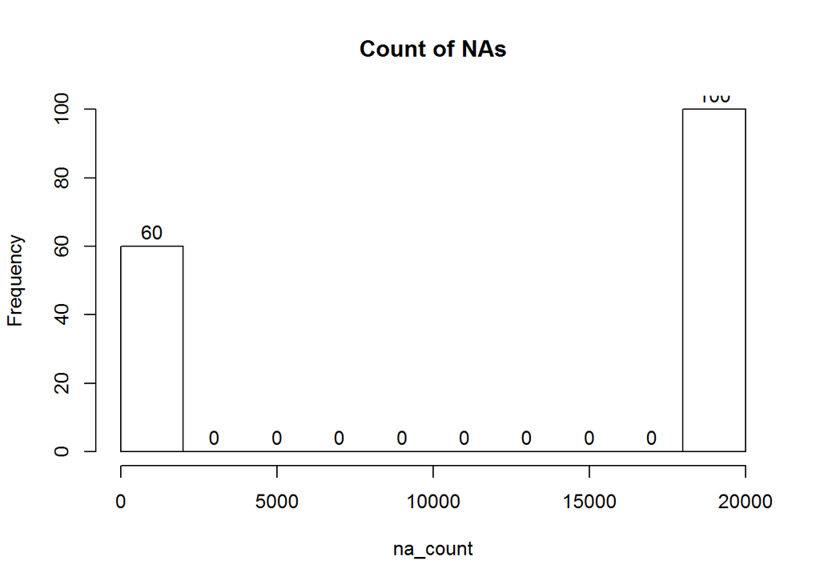

```r
na_count <-sapply(train, function(y) sum(length(which(is.na(y)))))
hist(na_count,labels=TRUE,main="Count of NAs")
```

```r
trim<-na_count > 1
train2 <- train[!trim]
col<- names(train2)
train3 <- train2[,-c(1:7)]
```

After the trimming was complete we created a subset within the training data to allow for testing of the model. The structure of the test data does not have the “classe” variable, so this allowed us to test the out-of-sample accuracy of any models holistically.

```r
set.seed(11232)
inTrain <- createDataPartition(y=train3$classe, p=0.70, list=FALSE)
mltrain <- train3[inTrain,]
mltest <- train3[-inTrain,]
```

Afterwards we created two models for comparison. A Gradient Boost Multinomial model that was continuously retuned to attempt to increase accuracy, and a Random Forest model.

Both of which used 10 cross-validation samples from the new training data subset.

```r
model<-gbm(classe~.,data=mltrain,interaction.depth=10,bag.fraction=.5,shrinkage=.001,n.trees=2000,cv.folds=10,n.minobsinnode=1,keep.data=FALSE)

model2<-train(classe~.,data=mltrain,method="rf",trControl=trainControl(method="cv",number=10))
```

These models were then used to predict the results for the “mltest” test dataset subsetted from the original training data.

```r
pred <-predict.gbm(model,newdata=mltest,n.trees=400,type="response")

predfix <- apply(pred, 1, which.max)
predfix[predfix==1]<-"A"
predfix[predfix==2]<-"B"
predfix[predfix==3]<-"C"
predfix[predfix==4]<-"D"
predfix[predfix==5]<-"E"

pred<-as.data.frame(pred)

pred2 <-predict(model2,mltest,type="prob")
pred2fix <-predict(model2,mltest)
```

Initially an attempt was going to be made to combine both models to potentially achieve greater out-of-sample results on the test data, but the outperformance of the random forest model ultimately resulted in it’s discretionary selection.

## Results

The results for the different models show a clear improvement with the random forest model over a tweaked and iterative gbm model.

```r
#GBM model
table(predfix,mltest$classe)
```

```
##
## predfix    A    B    C    D    E
##       A 1559  163    6   20   27
##       B   28  861  122   76   53
##       C   11   76  869   61   17
##       D   53   30   26  784   22
##       E   23    9    3   23  963
```

```r
#RF model
table(pred2fix,mltest$classe)
```

```
##
## pred2fix    A    B    C    D    E
##        A 1670   12    0    0    0
##        B    3 1125    8    0    0
##        C    0    2 1017   11    0
##        D    0    0    1  951    4
##        E    1    0    0    2 1078
```

Proceeding with the RF model, or “model2”, the next step was estimating our out of sample error rate, which, taking a look at the training-test data set of length 5885 and accurate predictions of 5841

Our out of sample rate is 0.0074766 or 0.7476636%

Finally for review here is a quick summary of the final model:

```r
print(model2)
```

```
## Random Forest
##
## 13737 samples
##    52 predictor
##     5 classes: 'A', 'B', 'C', 'D', 'E'
##
## No pre-processing
## Resampling: Cross-Validated (10 fold)
## Summary of sample sizes: 12362, 12363, 12363, 12364, 12364, 12363, ...
## Resampling results across tuning parameters:
##
##   mtry  Accuracy   Kappa
##    2    0.9925746  0.9906069
##   27    0.9923564  0.9903309
##   52    0.9829663  0.9784492
##
## Accuracy was used to select the optimal model using the largest value.
## The final value used for the model was mtry = 2.
```

For further analysis the delta of each step should be analyzed for each of the respective “performances” of an activity to see if there’s meaningful data that can be extracted from the respective derivative of our dataset.